# Aufgabenblatt 2

Car case study - Linerare Regression

Ömer Faruk Torun

2025-04-14

# Einleitung

In dieser Übung wird die lineare Regression als grundlegende Methode des maschinellen Lernens eingeführt. Ziel ist es, anhand des Auto-MPG-Datensatzes die Kraftstoffeffizienz / Beschleunigung etc. von Autos aus den 1970er und 1980er Jahren vorherzusagen. Dabei werden Sie lernen, Daten zu explorieren, vorzubereiten und mit einem Modell zu trainieren sowie die Ergebnisse zu evaluieren. Außerdem werden Cross-Validation und Workflows thematisiert, um die Konsistenz und Wiederholbarkeit der Modellierung zu verbessern.

Bitte lösen Sie die folgenden Aufgaben Schritt für Schritt und orientieren Sie sich dabei an den bereitgestellten Code-Snippets.

Hinweise und Erklärungen sind enthalten, um euch bei jedem Schritt zu unterstützen.

# 1. Datenexploration und Bereinigung

**Frage 1.1:** Importiert den Datensatz sample_car_dataset.csv und zeigt die ersten 10 Zeilen an. Welche Attribute sind im Datensatz enthalten?

```r
library(tidyverse) # Read .csv files
sample_cars <- read_csv("data/sample_car_dataset.csv") # Load the dataset
sample_cars %>%  head(10) # Show the first 10 rows of the dataset
```

```
## # A tibble: 10 × 9
##      mpg cylinders displacement horsepower weight acceleration model_year origin
##    <dbl>     <dbl>        <dbl>      <dbl>  <dbl>        <dbl>      <dbl>  <dbl>
##  1    15         8          350        165   3693         11.5         70      1
##  2    18         8          318        150   3436         11           70      1
##  3    16         8          304        150   3433         12           70      1
##  4    17         8          302        140   3449         10.5         70      1
##  5    15         8          429        198   4341         10           70      1
##  6    14         8          454        220   4354          9           70      1
##  7    14         8          440        215   4312          8.5         70      1
##  8    14         8          455        225   4425         10           70      1
##  9    15         8          390        190   3850          8.5         70      1
## 10    15         8          383        170   3563         10           70      1
## # ℹ 1 more variable: car_name <chr>
```

**Frage 1.2:** Untersuchen Sie den Datensatz auf fehlende Werte. Welche Spalten haben fehlende Werte?

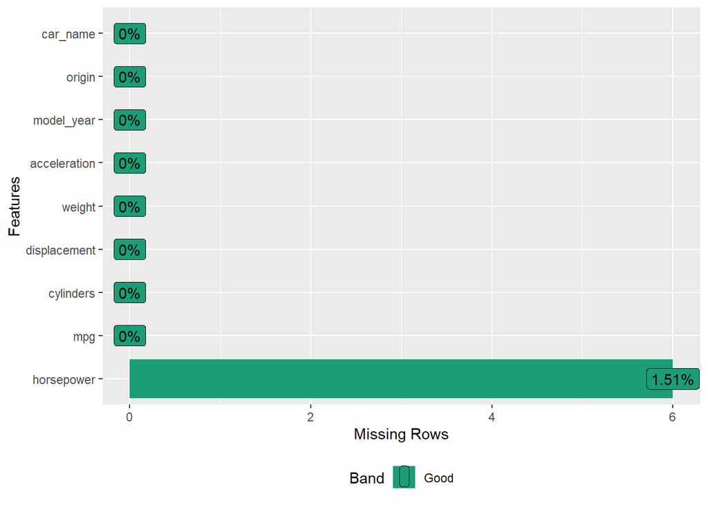

```r
library(DataExplorer) # Data exploration package
plot_missing(sample_cars) # Visualisieren Sie die fehlenden Datenpunkte
```

**Frage 1.3:** Führen Sie eine Imputation der Spalte horsepower durch. Welche Methode würden Sie wählen?

**Erklärung 1.3:** Imputation bedeutet, fehlende Werte durch plausible Werte zu ersetzen. Methoden wie “Mean Imputation” (Durchschnitt), “Median Imputation” oder modernere Techniken wie “Predictive Mean Matching” (PMM) können verwendet werden.

**Warum PMM?:** PMM nutzt ähnliche vorhandene Werte im Datensatz, um realistischere Imputationen durchzuführen, statt den Mittelwert zu nehmen.

```r
library(mice) # Imputation package
imputed_sample_cars <- mice(sample_cars,
  m = 2, # Number of imputed datasets
  maxit = 5, # Number of iterations
  method = "pmm", # Predictive Mean Matching
  seed = 123 # Set seed for reproducibility
) # Imputation using PMM
completed_sample_cars <- complete(imputed_sample_cars) # Complete the dataset
completed_sample_cars %>%
  select(car_name, horsepower) %>% # Select relevant columns
  head(20) # Show the first 10 rows of the completed dataset
```

```
##                        car_name horsepower
## 1             buick skylark 320        165
## 2            plymouth satellite        150
## 3                 amc rebel sst        150
## 4                   ford torino        140
## 5              ford galaxie 500        198
## 6              chevrolet impala        220
## 7             plymouth fury iii        215
## 8              pontiac catalina        225
## 9            amc ambassador dpl        190
## 10          dodge challenger se        170
## 11           plymouth 'cuda 340        160
## 12        chevrolet monte carlo        150
## 13      buick estate wagon (sw)        225
## 14        toyota corona mark ii         95
## 15              plymouth duster         95
## 16                   amc hornet         97
## 17                ford maverick         85
## 18                 datsun pl510         88
## 19 volkswagen 1131 deluxe sedan         46
## 20                  peugeot 504         87
```

# 2. Datenaufteilung und Verwendung von Rezepten

**Frage 2.1:** Warum ist es wichtig, die Daten in Trainings- und Testdaten aufzuteilen? Teilt die Daten im Verhältnis 70:30 auf.

**Erklärung 2.1:** Die Aufteilung trennt den Datensatz in zwei Teile: Trainingsdaten, um das Modell zu trainieren, und Testdaten, um die Leistung zu evaluieren. Dadurch vermeiden wir Overfitting, d. h., dass das Modell nur auf Trainingsdaten gut funktioniert, aber auf neuen Daten versagt.

```r
library(tidymodels)
set.seed(123) # Set seed for reproducibility
sample_cars_split <- initial_split(
  completed_sample_cars, # Split the dataset
  prop = 0.7 # Proportion of training data
) # Split the data into training and testing sets
train_data <- training(sample_cars_split) # Training data
test_data <- testing(sample_cars_split) # Testing data
```

**Frage 2.2:** Was sind Rezepte (`recipes`) und warum werden sie verwendet?

**Erklärung 2.2:** Rezepte in R (aus dem `recipes`-Paket) sind Werkzeuge zur Vorbereitung von Daten. Sie enthalten alle Schritte, um Rohdaten in ein Format zu bringen, das für maschinelles Lernen geeignet ist.

**Typische Schritte eines Rezepts sind:**

- Entfernen irrelevanter Spalten
- Normalisierung numerischer Variablen
- Erstellung von Dummy-Variablen für kategoriale Variablen
- Umgang mit fehlenden Werten

```r
library(recipes) # Recipe package
car_recipe_prep <- recipe(mpg ~ ., data = train_data) %>% # Create a recipe
  # Step 1: Entfernen irrelevanter Spalten
  step_rm(car_name) %>%
  # Step 2: Normalisierung numerischer Variablen:
  step_normalize(all_numeric(), -all_outcomes()) %>%
  # Step 3: Erstellung von Dummy-Variablen für kategoriale Variablen
  step_dummy(all_nominal(), -all_outcomes())
```

**Frage 2.3:** Warum ist es wichtig, numerische Variablen zu normalisieren und kategoriale Variablen in Dummies umzuwandeln?

**Erklärung 2.3:** Normalisierung numerischer Variablen ist wichtig, da viele maschinelle Lernalgorithmen empfindlich auf unterschiedliche Skalen der Eingabevariablen reagieren. Durch Normalisierung wird sichergestellt, dass alle numerischen Variablen denselben Wertebereich haben, was die Modellleistung verbessern kann.

Das Umwandeln kategorialer Variablen in Dummies ist notwendig, da maschinelle Lernalgorithmen in der Regel nur mit numerischen Daten arbeiten können. Dummy-Variablen kodieren kategoriale Daten in eine numerische Form, die vom Modell verarbeitet werden kann.

**Frage 2.4:** Was ist der Unterschied zwischen `lm(prepped_recipe, ...)` und `train(recipe, ..., method="lm")`?

**Erklärung 2.4:**

- Mit `lm(prepped_recipe, ...)` erstellt ihr ein lineares Regressionsmodell direkt aus einem vorbereiteten Datensatz. Das Rezept wird vorher angewandt.
- Mit `train(recipe, ..., method="lm")` wird das Rezept direkt in den Modell-Workflow integriert. Dabei erfolgt das Training und die Datenvorbereitung in einem Schritt, was einfacher ist und weniger Fehleranfälligkeit bietet.
1. Methode: `lm(prepped_recipe, ...)`

   ```r
   library(tidyverse) # For lm function
   # Prepare the recipe with training data:
   prepped <- prep(car_recipe_prep, training = train_data)
   # Apply the recipe to the training data
   train_processed <- bake(prepped, new_data = NULL)
   # Apply the recipe to the test data
   test_processed  <- bake(prepped, new_data = test_data)
   # Fit the linear model:
   model_lm <- lm(mpg ~ ., data = train_processed)
   ```

2. Methode: `train(recipe, ..., method="lm")`

   ```r
   library(caret) # For train function
   # Fit the linear model using the recipe directly:
   model_lm_recipe <- train(car_recipe_prep, data = train_data, method = "lm")
   ```

# 3. Modelltraining und Evaluation

**Frage 3.1:** Erstellen Sie ein lineares Regressionsmodell und berechnet den RMSE auf den Testdaten.

1. Für erste Methode: `lm(prepped_recipe, ...)`

   ```r
   # Vorhersagen auf Testdaten:
   predictions_lm <- predict(model_lm, newdata = test_processed)
   # Vorhersagen anzeigen:
   test_data %>%
     mutate(mpg_predictions = predictions_lm) %>%
     select(car_name, mpg, mpg_predictions) %>%
     head(10)
   ```

   ```
   ##                        car_name mpg mpg_predictions
   ## 1             buick skylark 320  15        13.95684
   ## 2                 amc rebel sst  16        15.04696
   ## 3              chevrolet impala  14        10.60458
   ## 4              pontiac catalina  14        10.23123
   ## 5         chevrolet monte carlo  15        14.33742
   ## 6               plymouth duster  22        19.13603
   ## 7                 ford maverick  21        20.94089
   ## 8                  datsun pl510  27        25.61344
   ## 9  volkswagen 1131 deluxe sedan  26        27.38283
   ## 10                  audi 100 ls  24        22.45535
   ```

   ```r
   # Berechnung des RMSE:
   rmse <- sqrt(mean((test_data$mpg - predictions_lm)^2))
   print(rmse) # RMSE ausgeben
   ```

   ```
   ## [1] 3.242637
   ```

2. Für zweite Methode: `train(recipe, ..., method="lm")`

   ```r
   # Vorhersagen auf Testdaten:
   predictions_lm_recipe <- predict(model_lm_recipe, newdata = test_data)
   # Vorhersagen anzeigen:
   test_data %>%
     mutate(mpg_predictions = predictions_lm_recipe) %>%
     select(car_name, mpg, mpg_predictions) %>%
     head(10)
   ```

   ```
   ##                        car_name mpg mpg_predictions
   ## 1             buick skylark 320  15        13.95684
   ## 2                 amc rebel sst  16        15.04696
   ## 3              chevrolet impala  14        10.60458
   ## 4              pontiac catalina  14        10.23123
   ## 5         chevrolet monte carlo  15        14.33742
   ## 6               plymouth duster  22        19.13603
   ## 7                 ford maverick  21        20.94089
   ## 8                  datsun pl510  27        25.61344
   ## 9  volkswagen 1131 deluxe sedan  26        27.38283
   ## 10                  audi 100 ls  24        22.45535
   ```

   ```r
   # Berechnung des RMSE:
   rmse <- sqrt(mean((test_data$mpg - predictions_lm_recipe)^2))
   print(rmse) # RMSE ausgeben
   ```

   ```
   ## [1] 3.242637
   ```

**Zusatsfrage 3.1.1:** Was sagt der RMSE über die Modellgüte aus?

**Erklärung 3.1.1:** Der RMSE (Root Mean Square Error) ist ein Maß für die durchschnittliche Abweichung der Vorhersagen vom tatsächlichen Wert. Ein niedriger RMSE deutet darauf hin, dass das Modell gut funktioniert und die Vorhersagen nahe an den tatsächlichen Werten liegen. Ein hoher RMSE weist auf eine schlechte Modellanpassung hin.

# 4. Cross-Validation und Modellvergleich

**Frage 4.1:** Führen Sie eine 5-fache Cross-Validation durch. Warum ist diese Methode besser/ schlechter?

**Erklärung 4.1:** Cross-Validation teilt die Trainingsdaten mehrfach auf (z. B. in 5 Teile) und trainiert das Modell auf 4 Teilen, während der fünfte zur Validierung genutzt wird. Dies wiederholt sich für alle Teile und liefert robustere Ergebnisse.

```r
control <- trainControl(method = "cv", number = 5) # 5-fold Cross-Validation
# Trainieren des Modells mit Cross-Validation:
model_cv <- train(
  car_recipe_prep, # Rezept
  data = train_data, # Trainingsdaten
  method = "lm", # Modelltyp
  trControl = control # Cross-Validation-Kontrolle
)
```

# 5. Modell speichern und wiederverwenden

**Frage 5.1:** Speichern Sie bitte das Modell und laden es neu, um Vorhersagen zu erstellen.

```r
if (!dir.exists("trained_models")) {
  dir.create("trained_models")
}
# Modell speichern
saveRDS(model_cv, "trained_models/linear_model.rds")
# Modell laden
loaded_model <- readRDS("trained_models/linear_model.rds")
predictions_loaded_models <- predict(loaded_model, newdata = test_data)
test_data %>%
  mutate(mpg_predictions = predictions_loaded_models) %>%
  select(car_name, mpg, mpg_predictions) %>%
  head(10)
```

```
##                        car_name mpg mpg_predictions
## 1             buick skylark 320  15        13.95684
## 2                 amc rebel sst  16        15.04696
## 3              chevrolet impala  14        10.60458
## 4              pontiac catalina  14        10.23123
## 5         chevrolet monte carlo  15        14.33742
## 6               plymouth duster  22        19.13603
## 7                 ford maverick  21        20.94089
## 8                  datsun pl510  27        25.61344
## 9  volkswagen 1131 deluxe sedan  26        27.38283
## 10                  audi 100 ls  24        22.45535
```